# Statistical Inference - Course project - Part 2

Christoph Wagner

03/05/2020

## 2.) The ToothGrowth dataset

The ToothGrowth dataset contains 60 observations of odontoblasts (cells which produce tooth growth) of guinea pigs. The animals received vitamin C in three different doses and by one of two different delivery methods.

The columns of the dataset contain the following variables:

- len: Length of the odontoblasts
- supp: Delivery method of vitamin C, either VC (Asorbic acid) or OJ (orange juice)
- dose: Dose of vitamin C in mg/day

## 3.) Basic summary of the data

First of all, we inspect the dataset using the standard summary functionality of R.

```r
data("ToothGrowth")
data<-ToothGrowth
str(data) #Determine data types and inspect content
```

```
## 'data.frame':    60 obs. of  3 variables:
##  $ len : num  4.2 11.5 7.3 5.8 6.4 10 11.2 11.2 5.2 7 ...
##  $ supp: Factor w/ 2 levels "OJ","VC": 2 2 2 2 2 2 2 2 2 2 ...
##  $ dose: num  0.5 0.5 0.5 0.5 0.5 0.5 0.5 0.5 0.5 0.5 ...
```

```r
summary(data) #Display basic statistics about the dataset
```

```
##       len        supp         dose
##  Min.   : 4.20   OJ:30   Min.   :0.500
##  1st Qu.:13.07   VC:30   1st Qu.:0.500
##  Median :19.25           Median :1.000
##  Mean   :18.81           Mean   :1.167
##  3rd Qu.:25.27           3rd Qu.:2.000
##  Max.   :33.90           Max.   :2.000
```

We can visualize a histogram over the len values of all observations using the hist function. Of course, this doesn’t provide much information because the measured odontoblasts were created under different conditions.

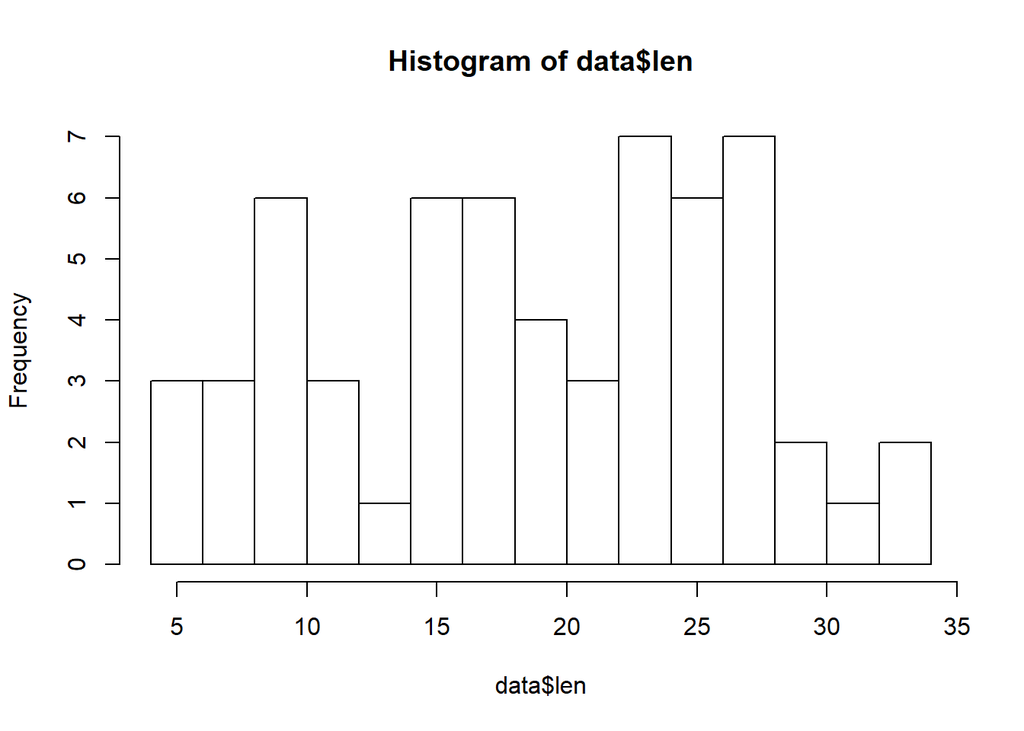

```r
hist(data$len, breaks=15)
```

Until now, the data don’t seem to follow the normal distribution.

If we plot the len values by dose, the graph indicates that len grows with higher dose value.

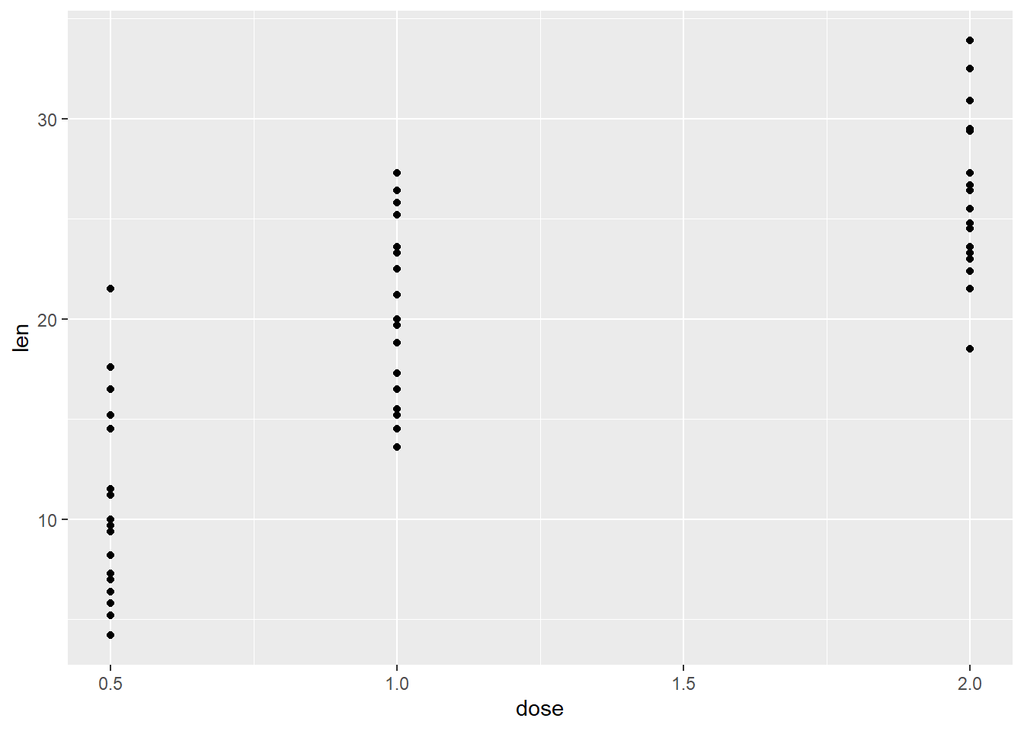

```r
library("ggplot2")
#ggplot(data, aes(x=dose, y=len))+geom_point()+facet_grid(cols=vars(supp))
ggplot(data, aes(x=dose, y=len))+geom_point()
```

In contrast, there is no indication that the growth differs for different applications methods of the vitamin. But they seem to spread more for supplement method “Asorbic Acid”.

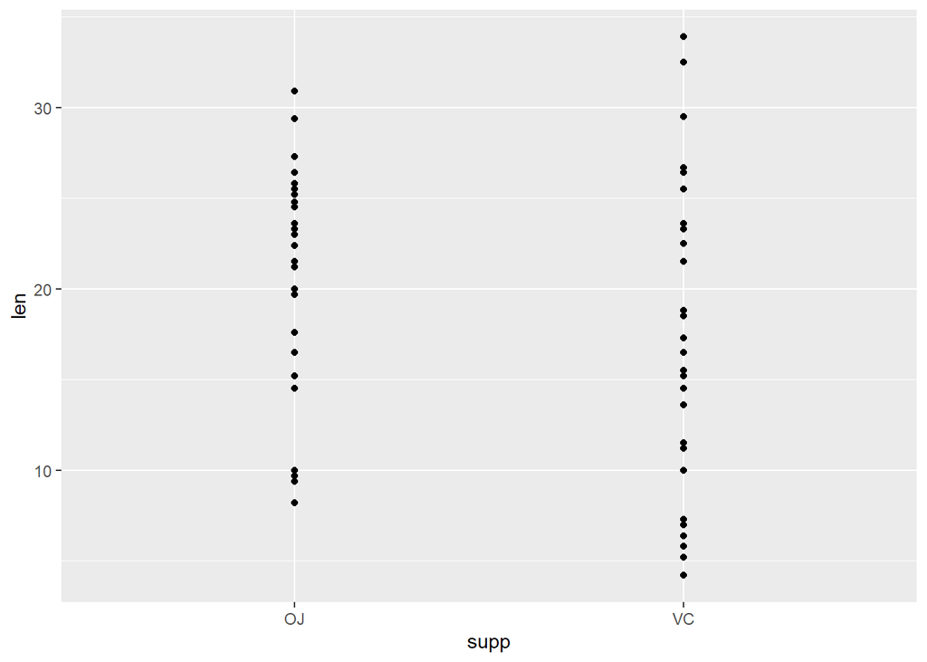

```r
ggplot(data, aes(x=supp, y=len))+geom_point()
```

All in all, at least there is indication that the len data differ depending on dose level. It is not obvious that they also differ by supplement method.

## 4.) Hypothesis tests: Tooth growth by supp and dose

In this chapter, we want create a test for the assumption that tooth growth differs significantly for different dose levels and supplement methods.

### 4.1) Tooth growth and supplement method

Null hypothesis (H_0): Len values of the tooth in average DON’T differ if vitamin C is applied via different supplement methods. Alternative hypothesis (H_a): Len values in average differ if vitamin C is applied via different supplement methods.

Assumptions: The len values of the two different supplement methods do not have the same variance (e.g. it could be possible that individuals have a different response to the application method). Additionally, the individuals are different and so, this is an unpaired test. Significance level 5 %.

```r
data_OJ<-data[data[,2]=="OJ",1]
data_VC<-data[data[,2]=="VC",1]
t_1<-t.test(data_OJ, data_VC, paired=FALSE, var.equal=FALSE, alternative="two.sided", conf.level=0.95)
```

Confidence interval: The difference of the means lies within [-0.1710156;7.5710156] with 95 % probability.

### 4.2) Tooth growth and dose level

Assumptions: As in 4.1) we assume differing variances. Test is unpaired. Significance level 5 %.

```r
data_05<-data[data[,3]==0.5,1]
data_10<-data[data[,3]==1.0,1]
data_20<-data[data[,3]==2.0,1]
t_1<-t.test(data_OJ, data_VC, paired=FALSE, var.equal=FALSE, alternative="two.sided", conf.level=0.95)
t_1
```

[output not shown]